# Resultados tesina

Omar Yaxmehen Bello-Chavolla

10 de marzo de 2020

# Análisis de regresión lineal múltiple

Primero evaluaremos la distribución general de los datos para tener una idea de las transformaciones que puedan ser necesarias:

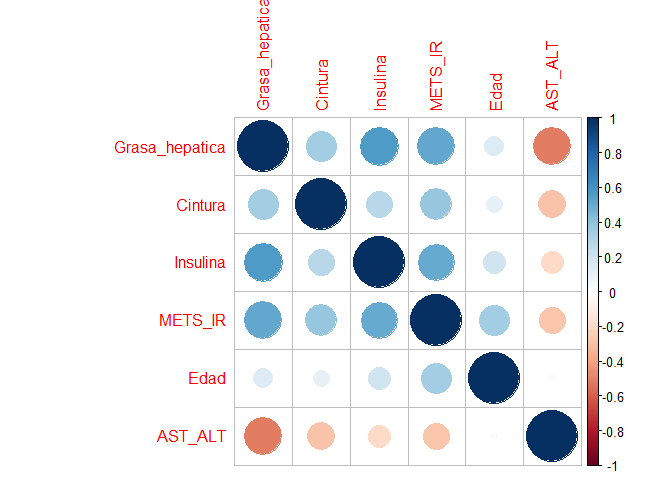

```r
correlacion_data<-cor(livergbm[c(3:7, 10)])
corrplot(correlacion_data, method="circle")
```

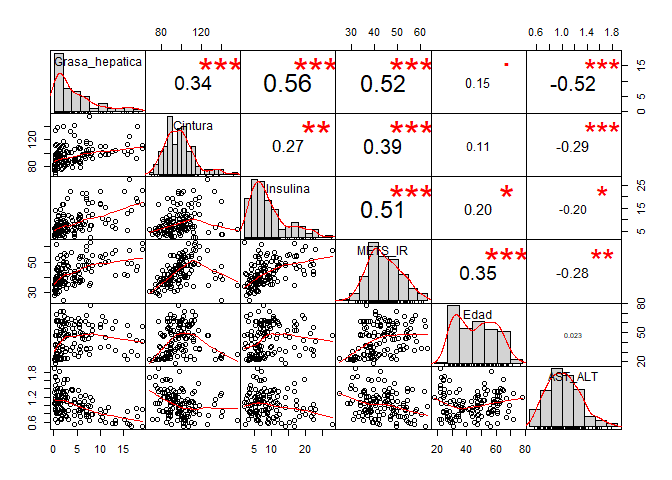

```r
chart.Correlation(livergbm[c(3:7, 10)], histogram=TRUE, pch=19)
```

```r
cor(livergbm[c(3:7, 10)])
```

```
##                Grasa_hepatica    Cintura   Insulina    METS_IR       Edad
## Grasa_hepatica      1.0000000  0.3446737  0.5635585  0.5195543 0.14839952
## Cintura             0.3446737  1.0000000  0.2729572  0.3880731 0.10828729
## Insulina            0.5635585  0.2729572  1.0000000  0.5090908 0.19696719
## METS_IR             0.5195543  0.3880731  0.5090908  1.0000000 0.34991492
## Edad                0.1483995  0.1082873  0.1969672  0.3499149 1.00000000
## AST_ALT            -0.5193484 -0.2873641 -0.1965852 -0.2761189 0.02283474
##                    AST_ALT
## Grasa_hepatica -0.51934838
## Cintura        -0.28736407
## Insulina       -0.19658516
## METS_IR        -0.27611885
## Edad            0.02283474
## AST_ALT         1.00000000
```

## Transformación de los datos

Como pudimos apreciar en los gráficos previos, los datos tienen distribuciones variables, algunos tienen sesgos positivos y distribuciones adimétricas. Debido a esto, se considera pertinente realizar tranformaciones generales para aproximar distribuciones normales.

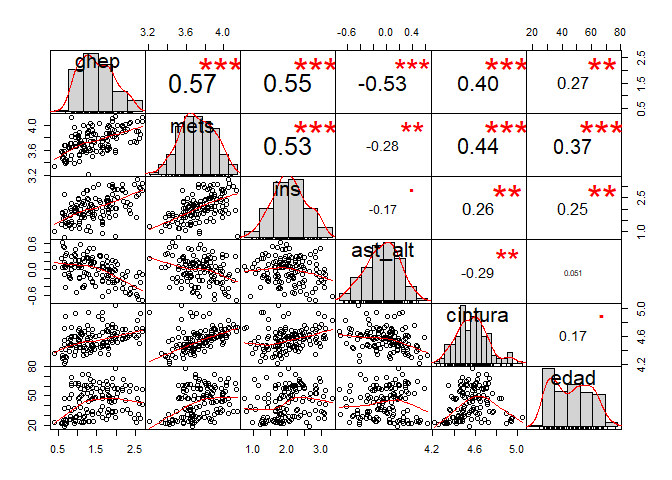

```r
ins<-log(livergbm$Insulina); ast_alt<-log(livergbm$AST_ALT)
mets<-log(livergbm$METS_IR); sex<-as.factor(livergbm$Sexo)
dm2<-as.factor(livergbm$DM2); ghep<-(livergbm$Grasa_hepatica)^(1/3)
cintura<-log(livergbm$Cintura); edad<-livergbm$Edad
dat<-data.frame(ghep, mets, ins, ast_alt, cintura,edad, sex, dm2)
chart.Correlation(dat[,1:6], histogram=TRUE, pch=19)
```

Las transformaciones logran distribuciones más simétricas y mejoran la relación lineal con la variable dependiente.

Se evaluó la influencia de observaciones categóricas sobre el desenlace

```r
t.test(ghep[sex==0], ghep[sex==1])
```

```
##
##  Welch Two Sample t-test
##
## data:  ghep[sex == 0] and ghep[sex == 1]
## t = -0.48214, df = 105.65, p-value = 0.6307
## alternative hypothesis: true difference in means is not equal to 0
## 95 percent confidence interval:
##  -0.2551453  0.1553278
## sample estimates:
## mean of x mean of y
##  1.434455  1.484364
```

```r
t.test(ghep[dm2==0], ghep[dm2==1])
```

```
##
##  Welch Two Sample t-test
##
## data:  ghep[dm2 == 0] and ghep[dm2 == 1]
## t = -3.8423, df = 126.41, p-value = 0.000192
## alternative hypothesis: true difference in means is not equal to 0
## 95 percent confidence interval:
##  -0.5532597 -0.1771003
## sample estimates:
## mean of x mean of y
##  1.265293  1.630473
```

### Observaciones influyentes

Para identificar observaciones influyentes, procedemos a ajustar un modelo RLM con todos los datos e identificamos observaciones influyentes basadas en COVRATIO, DIFFITS Y DIFFBETAS.

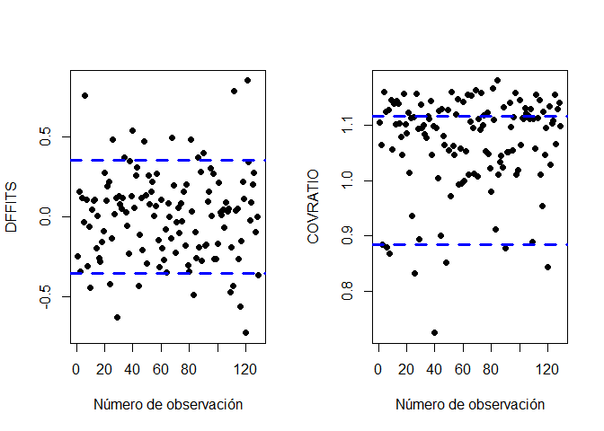

```r
#Ajustamos modelo
lm<-lm(ghep~., data=dat)
par(mfrow=c(1, 2))
DFFITS<-dffits(lm); plot(1:nrow(dat), DFFITS, pch = 19, cex = 1, xlab="Número de observación")
abline(h=2*(sqrt(4/nrow(dat))),  col="blue", lwd=3, lty=2)
abline(h=-2*(sqrt(4/nrow(dat))),  col="blue", lwd=3, lty=2)

COVRATIO<-covratio(lm); plot(1:nrow(dat), COVRATIO, pch = 19, cex = 1, xlab="Número de observación")
abline(h=((3*5)/nrow(dat))+1, col="blue", lwd=3, lty=2)
abline(h=-((3*5)/nrow(dat))+1, col="blue", lwd=3, lty=2)
```

```r
l1<-influence.measures(lm)
summary(l1) ##Se identificaron 40, 112 y 121 como influyentes
```

```
## Potentially influential observations of
##   lm(formula = ghep ~ ., data = dat) :
##
##     dfb.1_ dfb.mets dfb.ins dfb.ast_ dfb.cntr dfb.edad dfb.sex1 dfb.dm21
## 40   0.01  -0.01    -0.28   -0.22     0.04     0.08    -0.29     0.20
## 112 -0.23  -0.47    -0.02    0.13     0.64    -0.09    -0.06     0.06
## 121 -0.43   0.58    -0.65    0.11     0.10    -0.38    -0.07     0.33
##     dffit   cov.r   cook.d hat
## 40   0.54    0.72_*  0.03   0.04
## 112  0.78_*  1.16    0.08   0.21_*
## 121  0.85_*  1.13    0.09   0.21_*
```

En las gráficas de DFFITS y COVRATIO se obervan dmuchas observaciones que salen de los límites de confianza, sin embargo solamente 3 en DFFITS y una en COVRATIO podría considerarse como influyente. Utilizando la función `influence.measures` se identificaron a los sujetos 40, 112 y 121 como obervaciones influyentes. Para la separación de la base en entrenamiento y validación, se decidió excluir a los sujetos, para potencialmente tener un mejor ajuste.

## Separación de bases: Entrenamiento y validación.

```r
livergbm<-dat[-c(40, 112, 121),]
#Establecemos semilla para reproducibilidad
set.seed(45)
#Separamos la base general en una de entrenamiento (70%) y una de validación (30%).
liver1 <- initial_split(livergbm, prop = 0.70)
liver_train <- training(liver1)
liver_test  <- testing(liver1)
head(liver_train)
```

```
##       ghep     mets      ins     ast_alt  cintura edad sex dm2
## 1 1.910195 4.102015 2.990720 -0.25593337 4.770600   34   1   1
## 4 2.333719 4.018382 1.931521 -0.57251919 4.626932   54   0   1
## 5 2.228688 4.003089 2.734368 -0.53280453 4.703476   45   1   1
## 6 1.990791 3.593513 2.028148  0.18232156 4.570579   78   1   1
## 7 1.773691 3.962317 2.501436  0.00000000 4.767289   33   1   0
## 8 1.025986 3.840203 2.476538  0.04879016 4.565389   61   0   1
```

```r
dat1<-liver_train
```

## Ajuste y selección del modelo en la base de entrenamiento

```r
#Ajustamos modelo inicial
lm1<-lm(ghep~., data=dat1)
summary(lm1)
```

```
##
## Call:
## lm(formula = ghep ~ ., data = dat1)
##
## Residuals:
##      Min       1Q   Median       3Q      Max
## -0.75251 -0.27398  0.02568  0.21206  0.76122
##
## Coefficients:
##              Estimate Std. Error t value Pr(>|t|)
## (Intercept) -2.844697   1.335904  -2.129 0.036256 *
## mets         0.632312   0.289842   2.182 0.032040 *
## ins          0.332323   0.092468   3.594 0.000558 ***
## ast_alt     -0.714977   0.144706  -4.941 4.12e-06 ***
## cintura      0.247922   0.304575   0.814 0.418035
## edad         0.001131   0.003726   0.304 0.762278
## sex1        -0.105276   0.088852  -1.185 0.239547
## dm21         0.142338   0.117745   1.209 0.230234
## ---
## Signif. codes:  0 '***' 0.001 '**' 0.01 '*' 0.05 '.' 0.1 ' ' 1
##
## Residual standard error: 0.3648 on 81 degrees of freedom
## Multiple R-squared:  0.603,  Adjusted R-squared:  0.5687
## F-statistic: 17.58 on 7 and 81 DF,  p-value: 5.758e-14
```

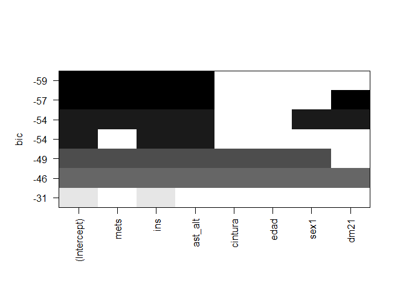

```r
##Seleccionamos nuevo modelo
library(leaps)
models <- regsubsets(ghep~., data = dat1, method = "seqrep")
m1<-summary(models)
plot(models)
```

```r
lm2<-lm(ghep~ast_alt+ins+mets+dm2, data=dat1)
summary(lm2)
```

```
##
## Call:
## lm(formula = ghep ~ ast_alt + ins + mets + dm2, data = dat1)
##
## Residuals:
##      Min       1Q   Median       3Q      Max
## -0.74327 -0.22858  0.02793  0.21276  0.74868
##
## Coefficients:
##             Estimate Std. Error t value Pr(>|t|)
## (Intercept) -1.95930    0.89432  -2.191   0.0312 *
## ast_alt     -0.70614    0.13385  -5.276 1.01e-06 ***
## ins          0.37561    0.08500   4.419 2.94e-05 ***
## mets         0.67645    0.25902   2.612   0.0107 *
## dm21         0.13754    0.08436   1.630   0.1067
## ---
## Signif. codes:  0 '***' 0.001 '**' 0.01 '*' 0.05 '.' 0.1 ' ' 1
##
## Residual standard error: 0.3631 on 84 degrees of freedom
## Multiple R-squared:  0.5921, Adjusted R-squared:  0.5727
## F-statistic: 30.48 on 4 and 84 DF,  p-value: 1.139e-15
```

```r
lm2<-lm(ghep~ast_alt+ins+mets+dm2, data=dat1)
c(BIC(lm1), BIC(lm2)); BIC(lm1) > BIC(lm2)
```

```
## [1] 105.06711  94.02389
```

```
## [1] TRUE
```

Como podemos ver, la diferencia entre ambos BIC values es considerable, por lo que puede determinarse que el modelo depurado es superior.

## Validación de supuestos

### Supuesto de linealidad

Para validar el supuesto de linealidad, realizaremos pruebas de falta de ajuste en cada uno de los coeficientes continuos, utilizando términos cuadráticos para cada variable:

```r
m1<-lm(ghep~mets+ins+ast_alt+dm2+I(mets^2), data=dat1)
anova(m1)[5,]
```

```
## Analysis of Variance Table
##
## Response: ghep
##           Df  Sum Sq Mean Sq F value Pr(>F)
## I(mets^2)  1 0.21309 0.21309  1.6284 0.2055
```

```r
m2<-lm(ghep~mets+ins+ast_alt+dm2+I(ins^2), data=dat1)
anova(m2)[5,]
```

```
## Analysis of Variance Table
##
## Response: ghep
##          Df   Sum Sq  Mean Sq F value Pr(>F)
## I(ins^2)  1 0.022344 0.022344  0.1678 0.6831
```

```r
m3<-lm(ghep~mets+ins+ast_alt+dm2+I(ast_alt^2), data=dat1)
anova(m3)[5,]
```

```
## Analysis of Variance Table
##
## Response: ghep
##              Df   Sum Sq  Mean Sq F value Pr(>F)
## I(ast_alt^2)  1 0.098556 0.098556  0.7453 0.3905
```

Como se puede apreciar en las salidas previas, ninguna de las variables viola el principio de linealidad, por lo que puede validarse éste supuesto.

### Supuesto de homoscedasticidad de varianza e independencia de los errores

Para validar el principio de homoscedasticidad de varianza se utilizará la prueba de Breusch-Pagan, así como la evaluación de gráficos de los residuos para comprobar la independencia de los errores.

```r
bptest(lm2, data = dat1, studentize = TRUE)
```

```
##
##  studentized Breusch-Pagan test
##
## data:  lm2
## BP = 2.0769, df = 4, p-value = 0.7216
```

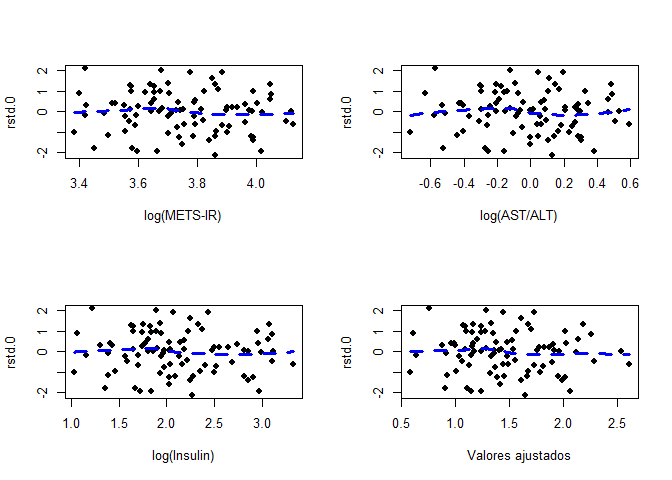

```r
rstd.0 <- stdres(lm2); par(mfrow=c(2,2)); x<-sort(dat1$mets)
lw1<-loess(rstd.0 ~ x,data=dat1)
plot(x, rstd.0, xlab="log(METS-IR)", pch = 19, cex = 1)
lines(x, lw1$fitted,col="blue",lwd=3, lty=2)
x1<-sort(dat1$ast_alt); lw2<-loess(rstd.0 ~ x1,data=dat1)
plot(x1, rstd.0, xlab="log(AST/ALT)", pch = 19, cex = 1)
lines(x1, lw2$fitted,col="blue",lwd=3, lty=2)
x2<-sort(dat1$ins); lw3<-loess(rstd.0 ~ x2,data=dat1)
plot(x2, rstd.0, xlab="log(Insulin)", pch = 19, cex = 1)
lines(x2, lw3$fitted,col="blue",lwd=3, lty=2)
x3<-sort(lm2$fitted); lw4<-loess(rstd.0 ~ x3,data=dat1)
plot(x3, rstd.0, xlab="Valores ajustados", pch = 19, cex = 1)
lines(x3, lw4$fitted,col="blue",lwd=3, lty=2)
```

Como puede apreciarse en la salida previa, la prueba de Breusch-Pagan no rechaza la hipótesis nula de homoscedasticidad de varianza para el modelo por lo cual puede determinarse que se cumple éste supuesto. En los gráficos de residuos vs. variables y valores ajustados se observan gráficos nulos por lo que hay homoscedasticidad de varianza y no hay dependencia en los errores.

### Matriz de diseño de rango completo

Para validar éste supuesto, evaluaremos la colinearidad de las variables en el modelo completo y en el modelo final, para validar que la colinearidad no influyó en la selección del modelo y que ésta no está presente en el modelo final. Para ésto calcularemos el índice de condición $\kappa$ y el factor de inflación de la varianza (VIF).

```r
##Supuesto de matriz de diseño de rango completo
#Evaluamos el índice kappa
X <- matrix(1, dim(dat1), 5)
X[,2:5] <- as.matrix(dat1[, c('mets', 'ast_alt', 'ins', 'dm2')])
kappa(X)
```

```
## [1] 67.93153
```

```r
#Ahora calculamos los VIF utilizando el paquete car
#Compararemos con el modelo con todaslas variables.
vif(lm2); vif(lm1)
```

```
##  ast_alt      ins     mets      dm2
## 1.082790 1.409637 1.548619 1.188687
```

```
##     mets      ins  ast_alt  cintura     edad      sex      dm2
## 1.921522 1.652857 1.254054 1.556300 2.189637 1.260118 2.294854
```

El valor del índice $\kappa$ es bajo y todos los VIF son menores a 5, por lo que puede establecerse que el modelo cumple el supuesto y no hay evidencia de multicolinealidad en el modelo.

### Normalidad conjunta de los errores

Para evaluar la normalidad conjunta de los errores primero exploraremos gráficamente los residuos y procederemos a probar su normalidad con la prueba de Anderson-Darling.

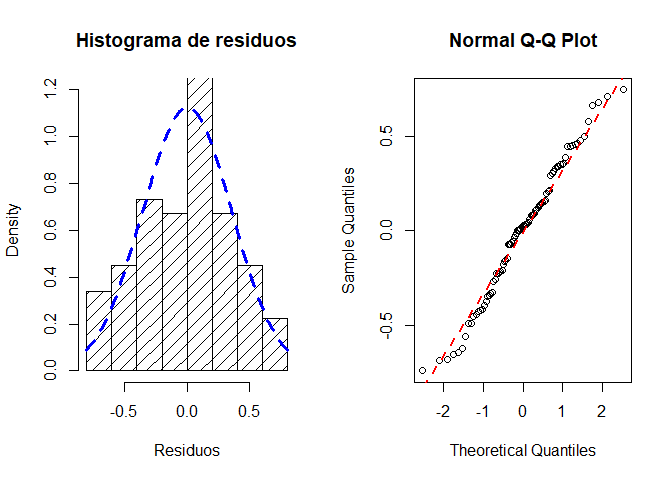

```r
##Supuesto de normalidad conjunta de los errores
par(mfrow=c(1, 2))
residuos<-lm2$residuals
hist(residuos, density=10, breaks=10, prob=TRUE, xlab="Residuos", ylim=c(0, 1.2),main="Histograma de residuos")
x<-residuos; m<-mean(residuos); std<-sd(residuos)
curve(dnorm(x, m, std), add=TRUE, lty=2, col="blue", lwd=3)

qqnorm(residuos); qqline(residuos, col = 2,lwd=2,lty=2)
```

```r
#Prueba de Anderson-Darling
ad.test(residuos)
```

```
##
##  Anderson-Darling normality test
##
## data:  residuos
## A = 0.35154, p-value = 0.4615
```

Como puede observarse en los gráficos previos y en la salida de `R`, no hay evidencia de que los residuos no sigan una distribución normal, por lo que puede determinarse que el modelo cumple con éste supuesto.

## Análisis final del modelo

Para el análisis final del modelo, evaluaremos si los intervalos de confianza simultáneos de los coeficientes son significativos cuando se consideran en conjunto utilizando el método de Hotelling-Scheffé, dado que estimaremos la simultaneidad en 5 coeficientes incluyendo al intercepto.

```r
K <- cbind(diag(length(coef(lm2))))
rownames(K) <- names(coef(lm2))
sim <- glht(lm2, linfct = K)
confint(sim, level = 0.95)
```

```
##
##   Simultaneous Confidence Intervals
##
## Fit: lm(formula = ghep ~ ast_alt + ins + mets + dm2, data = dat1)
##
## Quantile = 2.5472
## 95% family-wise confidence level
##
##
## Linear Hypotheses:
##                  Estimate lwr      upr
## (Intercept) == 0 -1.95930 -4.23730  0.31870
## ast_alt == 0     -0.70614 -1.04708 -0.36520
## ins == 0          0.37561  0.15909  0.59213
## mets == 0         0.67645  0.01669  1.33621
## dm21 == 0         0.13754 -0.07733  0.35241
```

```r
#Ajustamos los valores
pred.lm<-(predict(lm2, newdata =liver_test))^3
liver<-liver_test$ghep^3
```

# Self-normalizing neural network (Red neuronal auto-normalizable)

```r
train_data <- liver_train[,2:8]
test_data <- liver_test[,2:8]
train_targets<-liver_train$ghep
test_targets<-liver_test$ghep
m1 <- apply(train_data[,c(1:5)], 2, mean)
std <- apply(train_data[,c(1:5)], 2, sd)
train_data <- scale(train_data[,c(1:5)], center = m1, scale = std)
test_data <- scale(test_data[,c(c(1:5))], center = m1, scale = std)
train_data<-as.matrix(as.data.frame(cbind(train_data, liver_train$sex, liver_train$dm2)))
test_data<-as.matrix(as.data.frame(cbind(test_data, liver_test$sex, liver_test$dm2)))
```

## Arquitectura de la red

Se diseñó una red neuronal con 2 capas ocultas

-**Segunda capa oculta**: Una función *layer_dropout* para eliminar neuronas con contirbución <10%, para prevenir el sobreajuste.

-**Capa de salida**: Se utilizó una función softplus para evitar valores negativos. La función softplus se define como: $f(x)=log(1+e^x)$ y es una función estrictamente creciente.

-**Optimizador**: Se utilizó como optimizador ADAM.

```r
set.seed(123)
build_model <- function() {
  model <- keras_model_sequential() %>%
    layer_dense(units = 8, kernel_initializer='lecun_normal', activation="selu",input_shape = dim(train_data)[[2]]) %>%
    layer_alpha_dropout(rate=0.10) %>%
    layer_dense(units = 1, activation='softplus')

  model %>% compile(
    optimizer = "adam",
    loss = "mse",
    metrics = c("mae")
  )
}
```

## Cálculo de la métrica de error

```r
print(history)
```

```
## Trained on 67 samples (batch_size=1, epochs=50)
## Final epoch (plot to see history):
##                    loss: 0.1542
##     mean_absolute_error: 0.3211
##                val_loss: 0.2082
## val_mean_absolute_error: 0.347
```

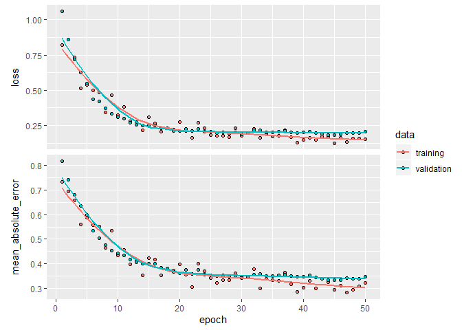

```r
plot(history)
```

Como podemos ver en la gráfica previa, identificamos que con $n=50$ épocas lográbamos un error cuadrático absoluto relativamente bajo. Ahora procedemos a esquematizar la arquitectura general de la red neuronal utilizada.

```r
#Reiniciamos el modelo, ajustamos por el número óptimo de épocas
model <- build_model()
summary(model)
```

```
## ___________________________________________________________________________
## Layer (type)                     Output Shape                  Param #
## ===========================================================================
## dense_8 (Dense)                  (None, 8)                     64
## ___________________________________________________________________________
## alpha_dropout_4 (AlphaDropout)   (None, 8)                     0
## ___________________________________________________________________________
## dense_9 (Dense)                  (None, 1)                     9
## ===========================================================================
## Total params: 73
## Trainable params: 73
## Non-trainable params: 0
## ___________________________________________________________________________
```

```r
#Se entrena el modelo en la base completa
set.seed(123)
model %>% fit(train_data, train_targets,
              epochs = 50, batch_size = 1, verbose = )
print(history)
```

```
## Trained on 67 samples (batch_size=1, epochs=50)
## Final epoch (plot to see history):
##                    loss: 0.1542
##     mean_absolute_error: 0.3211
##                val_loss: 0.2082
## val_mean_absolute_error: 0.347
```

##Evaluación del modelo

Finalmente, evaluamos el desempeño del modelo ajustado y calculamos los valores ajustados con el modelo final.

```r
#Evaluamos el modelo en la base de validación

result <- model %>% evaluate(test_data, test_targets)

result
```

```
## $loss
## [1] 0.1441165
##
## $mean_absolute_error
## [1] 0.3050368
```

```r
#Ajustamos los valores de validación
pred.nn <- predict(model, as.matrix(test_data))^3
```

# Gradient Boosting Machine

El gradient-boosting machine es un algoritmo diseñado para generar un modelo con mayor capacidad predictiva compuesto a partir de modelos con baja capacidad predictiva. Algunos de los hiperparámetros que deben ajustarse en el algoritmo para optimizar su función son:

-**Tasa de aprendizaje**: Codificado como `shrinkage`en el paquete `gbm`. Determina el factor por el cual se ajusta el modelo en cada iteración.

-**Profundidad de interacción**: Codificado como `interaction.depth` indica la profundidad máxima de los árboles utilizados en el modelo.

-**Observaciones en nodos terminales**: Codificado como `n.minobsinnode`indica el número mínimo de observaciones requeridos en cada nodo termina.

-**Submuestras**: Codificado como `bag.fraction`indica el porcentaje de los datos de entrenamiento a muestrear para cada árbol en el modelo.

-**Fracción de entrenamiento**: Codificado como `train.fraction` indica el porcentaje de observaciones a muestrear para cada árbol, utilizando el resto de las observacuiones para estimar la función de pérdida.

Ajustaremos el parámetro con los valores transformados y centrados, siguiendo un input similar al utilizado para la SNNN Para la optimización de los parámetros diseñamos una matriz con diferentes valores a probar por cross-validation utilizando el siguiente código:

```r
set.seed(123)
##Evaluacion de los parametros de ajuste

# create hyperparameter grid
hyper_grid <- expand.grid(
  shrinkage = c(.1, .2, .4),
  interaction.depth = c(1, 3, 5),
  n.minobsinnode = c(5, 7, 10),
  bag.fraction = c(.65, .8, 1),
  optimal_trees = 0,               # a place to dump results
  min_RMSE = 0                     # a place to dump results
)


# total number of combinations
nrow(hyper_grid)
```

```
## [1] 81
```

Como podemos observar, se iterará el modelo para un total de 81 combinaciones de hiperparámetros con el objetivo de encontrar la combinación que minimice la función de pérdida, establecida como la raíz cuadrada de la suma del cuadrado de los errores (RMSE).

```r
# grid search

train_data<-as.data.frame(train_data)
for(i in 1:nrow(hyper_grid)) {

  # reproducibility
  set.seed(123)

  # train model
  gbm.tune <- gbm(
    formula = train_targets ~ .,
    distribution = "gaussian",
    data = train_data,
    n.trees = 5000,
    interaction.depth = hyper_grid$interaction.depth[i],
    shrinkage = hyper_grid$shrinkage[i],
    n.minobsinnode = hyper_grid$n.minobsinnode[i],
    bag.fraction = hyper_grid$bag.fraction[i],
    train.fraction = 0.75,
    n.cores = NULL, # will use all cores by default
    verbose = FALSE
  )

  # add min training error and trees to grid
  hyper_grid$optimal_trees[i] <- which.min(gbm.tune$valid.error)
  hyper_grid$min_RMSE[i] <- sqrt(min(gbm.tune$valid.error))
}

hyper_grid %>%
  dplyr::arrange(min_RMSE) %>%
  head(10)
```

```
##    shrinkage interaction.depth n.minobsinnode bag.fraction optimal_trees
## 1        0.1                 1              5         0.65            43
## 2        0.1                 1             10         0.65            43
## 3        0.4                 5              5         1.00             4
## 4        0.1                 1              7         0.65            49
## 5        0.4                 5              5         0.80             8
## 6        0.2                 1             10         0.80            17
## 7        0.2                 1              7         0.80            19
## 8        0.2                 3             10         0.65            17
## 9        0.2                 5             10         0.65            17
## 10       0.4                 5              7         1.00             5
##     min_RMSE
## 1  0.3597741
## 2  0.3628153
## 3  0.3629227
## 4  0.3712198
## 5  0.3755852
## 6  0.3757287
## 7  0.3762185
## 8  0.3764829
## 9  0.3764829
## 10 0.3776524
```

```r
##Ajustamos el modelo con los parÃ¡metros corregidos
set.seed(123)

# train GBM model
gbm.fit <- gbm(
  formula = train_targets ~ .,
  distribution = "gaussian",
  data = train_data,
  n.trees = 12,
  interaction.depth = 3,
  shrinkage = 0.4,
  n.minobsinnode = 10,
  bag.fraction = 0.65,
  train.fraction = 1,
  cv.folds = 10,
  n.cores = NULL, # will use all cores by default
  verbose = FALSE
)

# print results
print(gbm.fit)
```

```
## gbm(formula = train_targets ~ ., distribution = "gaussian", data = train_data,
##     n.trees = 12, interaction.depth = 3, n.minobsinnode = 10,
##     shrinkage = 0.4, bag.fraction = 0.65, train.fraction = 1,
##     cv.folds = 10, verbose = FALSE, n.cores = NULL)
## A gradient boosted model with gaussian loss function.
## 12 iterations were performed.
## The best cross-validation iteration was 8.
## There were 7 predictors of which 7 had non-zero influence.
```

```r
#MSE y grÃ¡fico del modelo
sqrt(min(gbm.fit$cv.error))
```

```
## [1] 0.4225939
```

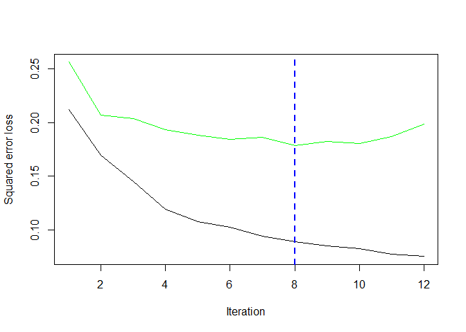

```
## [1] 8
```

```r
gbm.perf(gbm.fit, method = "cv")
```

```r
#Importancia de las variables
par(mar = c(5, 8, 1, 1))
summary(
  gbm.fit,
  cBars = 10,
  method = relative.influence, # also can use permutation.test.gbm
  las = 2
)
```

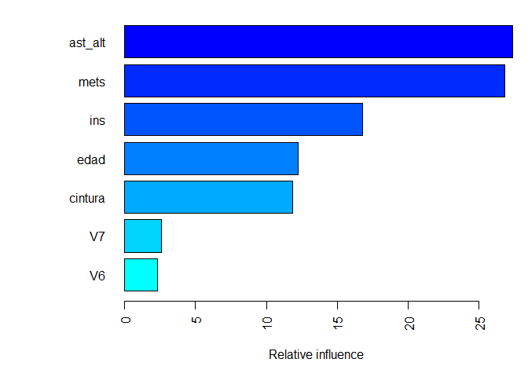

```
##             var   rel.inf
## ast_alt ast_alt 27.373715
## mets       mets 26.798473
## ins         ins 16.796682
## edad       edad 12.225649
## cintura cintura 11.855757
## V7           V7  2.627610
## V6           V6  2.322114
```

```r
# predict values for test data
test_data<-as.data.frame(test_data)
pred.gbm <- predict(gbm.fit, n.trees = gbm.fit$n.trees, test_data)^3
```

# Comparación de los modelos

```r
#Mean absolute error
mae.lm<-sum(abs(liver-pred.lm))/length(liver)
mae.nn<-sum(abs(liver-pred.nn))/length(liver)
mae.gbm<-sum(abs(liver-pred.gbm))/length(liver)

c(mae.lm, mae.nn, mae.gbm)
```

```
## [1] 2.142378 2.020812 2.227009
```

```r
#Root of mean squared error
rmse.lm<-sqrt(sum((liver-pred.lm)^2)/length(liver))
rmse.nn<-sqrt(sum((liver-pred.nn)^2)/length(liver))
rmse.gbm<-sqrt(sum((liver-pred.gbm)^2)/length(liver))
c(rmse.lm, rmse.nn, rmse.gbm)
```

```
## [1] 3.042266 2.669380 3.220597
```

```r
#Mean squared error
mse.lm<-sum((liver-pred.lm)^2)/length(liver)
mse.nn<-sum((liver-pred.nn)^2)/length(liver)
mse.gbm<-sum((liver-pred.gbm)^2)/length(liver)

c(mse.lm, mse.nn, mse.gbm)
```

```
## [1]  9.255382  7.125591 10.372247
```

```r
#Correlación y R^2
c(cor(liver, pred.lm), cor(liver, pred.lm)^2)
```

```
## [1] 0.8341931 0.6958782
```

```r
c(cor(liver, pred.nn), cor(liver, pred.nn)^2)
```

```
## [1] 0.8302520 0.6893183
```

```r
c(cor(liver, pred.gbm), cor(liver, pred.gbm)^2)
```

```
## [1] 0.7566083 0.5724562
```

```r
#Correlación y R^2
var(pred.lm);var(pred.gbm); var(pred.nn)
```

```
## [1] 7.610452
```

```
## [1] 11.36762
```

```
##          [,1]
## [1,] 13.85837
```

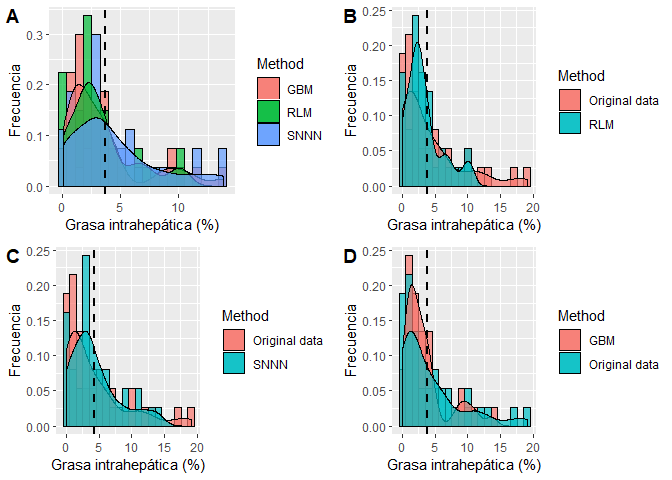

```r
#Graph
liver.pred<-c(pred.lm, pred.nn, pred.gbm)
Method<-c(rep("RLM", length(liver)), rep("SNNN", length(liver)), rep("GBM", length(liver)))
liver1<-data.frame(liver.pred, Method)
liver.lm<-c(liver, pred.lm)
Method<-c(rep("Original data", length(liver)), rep("RLM", length(liver)))
liver2<-data.frame(liver.lm, Method)
liver.nn<-c(liver, pred.nn)
Method<-c(rep("Original data", length(liver)), rep("SNNN", length(liver)))
liver3<-data.frame(liver.nn, Method)
liver.gbm<-c(liver, pred.gbm)
Method<-c(rep("Original data", length(liver)), rep("GBM", length(liver)))
liver4<-data.frame(liver.gbm, Method)
plot_multi_histogram <- function(df, feature, label_column) {
    plt <- ggplot(df, aes(x=eval(parse(text=feature)), fill=eval(parse(text=label_column)))) +
    geom_histogram(alpha=0.7, position="identity", aes(y = ..density..), color="black", bins=20) +
    geom_density(alpha=0.7) +
    geom_vline(aes(xintercept=mean(eval(parse(text=feature)))), color="black", linetype="dashed", size=1) +
    labs(x=feature, y = "Density")
    plt + guides(fill=guide_legend(title=label_column))
}
par(mfrow=c(2,2))
p1<-plot_multi_histogram(liver1, 'liver.pred', 'Method')+xlab("Grasa intrahepática (%)")+ylab("Frecuencia")
p2<-plot_multi_histogram(liver2, 'liver.lm', 'Method')+xlab("Grasa intrahepática (%)")+ylab("Frecuencia")
p3<-plot_multi_histogram(liver3, 'liver.nn', 'Method')+xlab("Grasa intrahepática (%)")+ylab("Frecuencia")
p4<-plot_multi_histogram(liver4, 'liver.gbm', 'Method')+xlab("Grasa intrahepática (%)")+ylab("Frecuencia")

plot_grid(p1,p2,p3,p4, labels = c("A", "B", "C","D"))
```

```r
#Gráficos de Bland-Altman
stats1<-blandr.statistics(liver, pred.lm, sig.level = 0.95, LoA.mode = 1)
c(stats1$bias, stats1$biasUpperCI, stats1$biasLowerCI)
```

```
## [1]  0.90283648  1.88484435 -0.07917139
```

```r
c(stats1$upperLOA, stats1$upperLOA_upperCI, stats1$upperLOA_lowerCI)
```

```
## [1] 6.675601 8.369125 4.982076
```

```r
c(stats1$lowerLOA, stats1$lowerLOA_upperCI, stats1$lowerLOA_lowerCI)
```

```
## [1] -4.869928 -3.176403 -6.563452
```

```r
b.lm<-blandr.plot.ggplot(stats1, method1name = "MRI-S",
  method2name = "Multiple linear regression",
  plotTitle = NULL,
  ciDisplay = TRUE, ciShading = TRUE, normalLow = FALSE,
  normalHigh = FALSE, overlapping = FALSE, x.plot.mode = "means",
  y.plot.mode = "difference", plotProportionalBias = FALSE,
  plotProportionalBias.se = TRUE, assume.differences.are.normal = TR)

stats2<-blandr.statistics(liver, pred.nn, sig.level = 0.95, LoA.mode = 1)
c(stats2$bias, stats2$biasUpperCI, stats2$biasLowerCI)
```

```
## [1] -0.1267566  0.7745179 -1.0280310
```

```r
c(stats2$upperLOA, stats2$upperLOA_upperCI, stats2$upperLOA_lowerCI)
```

```
## [1] 5.171414 6.725709 3.617118
```

```r
c(stats2$lowerLOA, stats2$lowerLOA_upperCI, stats2$lowerLOA_lowerCI)
```

```
## [1] -5.424927 -3.870631 -6.979223
```

```r
b.nn<-blandr.plot.ggplot(stats2, method1name = "MRI-S",
  method2name = "Feed-forward neural network",
  plotTitle = NULL,
  ciDisplay = TRUE, ciShading = TRUE, normalLow = FALSE,
  normalHigh = FALSE, overlapping = FALSE, x.plot.mode = "means",
  y.plot.mode = "difference", plotProportionalBias = FALSE,
  plotProportionalBias.se = TRUE, assume.differences.are.normal = TR)

stats3<-blandr.statistics(liver, pred.gbm, sig.level = 0.95, LoA.mode = 1)
c(stats3$bias, stats3$biasUpperCI, stats3$biasLowerCI)
```

```
## [1]  0.7872729  1.8428590 -0.2683132
```

```r
c(stats3$upperLOA, stats3$upperLOA_upperCI, stats3$upperLOA_lowerCI)
```

```
## [1] 6.992569 8.812983 5.172155
```

```r
c(stats3$lowerLOA, stats3$lowerLOA_upperCI, stats3$lowerLOA_lowerCI)
```

```
## [1] -5.418023 -3.597609 -7.238438
```

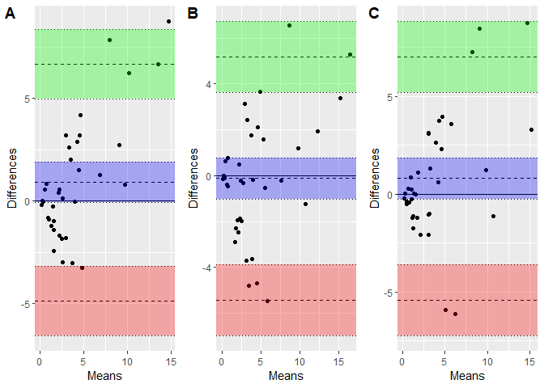

```r
b.gbm<-blandr.plot.ggplot(stats3, method1name = "MRI-S",
  method2name = "Gradient-boosting machine",
  plotTitle = NULL,
  ciDisplay = TRUE, ciShading = TRUE, normalLow = FALSE,
  normalHigh = FALSE, overlapping = FALSE, x.plot.mode = "means",
  y.plot.mode = "difference", plotProportionalBias = FALSE,
  plotProportionalBias.se = TRUE, assume.differences.are.normal = TR)
plot_grid(b.lm, b.nn, b.gbm, labels = c("A", "B", "C"), ncol = 3)
```

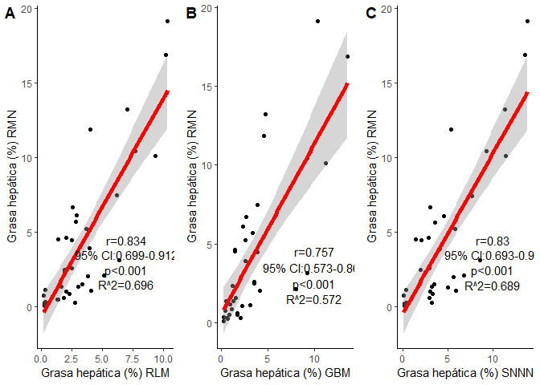

```r
stats<-data.frame(liver,pred.lm, pred.gbm, pred.nn)
c1<-cor.test(stats$liver,stats$pred.lm,method="pearson",conf.level = 0.95, nrep = 1000)
g1<-ggplot(stats, aes(x=pred.lm,y=liver))+geom_point()+
  geom_smooth(method = "lm", formula = y ~ x,color="red", size=2)+
  xlab("Grasa hepática (%) RLM")+
  ylab("Grasa hepática (%) RMN")+theme_classic()+
  annotate("text", x = 7, y = 4.5, label = paste0("r=",round(c1$estimate, 3)))+
  annotate("text", x = 7, y = 3.5, label = paste0("95% CI:",round(c1$conf.int[1],3),"-",round(c1$conf.int[2],3)))+
  annotate("text", x = 7, y = 2.5, label = paste0("p<0.001"))+
  annotate("text", x = 7, y = 1.5, label = paste0("R^2=",round(summary(lm(stats$liver~stats$pred.lm))$r.squared,3)))
c1<-cor.test(stats$liver,stats$pred.gbm,method="pearson",conf.level = 0.95, nrep = 1000)
g2<-ggplot(stats, aes(x=pred.gbm,y=liver))+geom_point()+
  geom_smooth(method = "lm", formula = y ~ x,color="red", size=2)+
  xlab("Grasa hepática (%) GBM")+
  ylab("Grasa hepática (%) RMN")+theme_classic()+
  annotate("text", x = 10, y = 4.5, label = paste0("r=",round(c1$estimate, 3)))+
  annotate("text", x = 10, y = 3.5, label = paste0("95% CI:",round(c1$conf.int[1],3),"-",round(c1$conf.int[2],3)))+
  annotate("text", x = 10, y = 2.5, label = paste0("p<0.001"))+
  annotate("text", x = 10, y = 1.5, label = paste0("R^2=",round(summary(lm(stats$liver~stats$pred.gbm))$r.squared,3)))
c1<-cor.test(stats$liver,stats$pred.nn,method="pearson",conf.level = 0.95, nrep = 1000)
g3<-ggplot(stats, aes(x=pred.nn,y=liver))+geom_point()+
  geom_smooth(method = "lm", formula = y ~ x,color="red", size=2)+
  xlab("Grasa hepática (%) SNNN")+
  ylab("Grasa hepática (%) RMN")+theme_classic()+
  annotate("text", x = 10, y = 4.5, label = paste0("r=",round(c1$estimate, 3)))+
  annotate("text", x = 10, y = 3.5, label = paste0("95% CI:",round(c1$conf.int[1],3),"-",round(c1$conf.int[2],3)))+
  annotate("text", x = 10, y = 2.5, label = paste0("p<0.001"))+
  annotate("text", x = 10, y = 1.5, label = paste0("R^2=",round(summary(lm(stats$liver~stats$pred.nn))$r.squared,3)))

fig<-plot_grid(g1,g2,g3, labels=c("A", "B", "C"), ncol=3, nrow=1)
fig
```

```r
library(pROC); library(OptimalCutpoints)
nafld1<-NULL; nafld1[liver>5.5]<-1; nafld1[!liver>5.5]<-0
roc(nafld1, pred.lm, ci = TRUE)
```

```
##
## Call:
## roc.default(response = nafld1, predictor = pred.lm, ci = TRUE)
##
## Data: pred.lm in 27 controls (nafld1 0) < 10 cases (nafld1 1).
## Area under the curve: 0.8926
## 95% CI: 0.7838-1 (DeLong)
```

```r
roc(nafld1, pred.nn,ci = TRUE)
```

```
##
## Call:
## roc.default(response = nafld1, predictor = pred.nn, ci = TRUE)
##
## Data: pred.nn in 27 controls (nafld1 0) < 10 cases (nafld1 1).
## Area under the curve: 0.8889
## 95% CI: 0.778-0.9998 (DeLong)
```

```r
roc(nafld1, pred.gbm,ci = TRUE)
```

```
##
## Call:
## roc.default(response = nafld1, predictor = pred.gbm, ci = TRUE)
##
## Data: pred.gbm in 27 controls (nafld1 0) < 10 cases (nafld1 1).
## Area under the curve: 0.8889
## 95% CI: 0.7839-0.9938 (DeLong)
```

```r
liver2<-data.frame(nafld1, pred.lm, pred.nn, pred.gbm)

# Defaut method
lm <- optimal.cutpoints(X = "pred.lm", status = "nafld1", tag.healthy = 0,
methods = "Youden", data = liver2, pop.prev = NULL, control = control.cutpoints(), ci.fit = TRUE, conf.level = 0.95, trace = FALSE)
summary(lm)
```

```
##
## Call:
## optimal.cutpoints.default(X = "pred.lm", status = "nafld1", tag.healthy = 0,
##     methods = "Youden", data = liver2, pop.prev = NULL, control = control.cutpoints(),
##     ci.fit = TRUE, conf.level = 0.95, trace = FALSE)
##
## Area under the ROC curve (AUC):  0.893 (0.784, 1.001)
##
## CRITERION: Youden
## Number of optimal cutoffs: 1
##
##                    Estimate 95% CI lower limit 95% CI upper limit
## cutoff            2.5289156                  -                  -
## Se                1.0000000          0.6915029                NaN
## Sp                0.6666667          0.4603927          0.8348118
## PPV               0.5263158          0.3215738                NaN
## NPV               1.0000000          0.8013800          1.0000000
## DLR.Positive      3.0000000          1.7597604          5.1143326
## DLR.Negative      0.0000000          0.0000000                NaN
## FP                9.0000000                  -                  -
## FN                0.0000000                  -                  -
## Optimal criterion 0.6666667                  -                  -
```

```r
nn <- optimal.cutpoints(X = "pred.nn", status = "nafld1", tag.healthy = 0,
methods = "Youden", data = liver2, pop.prev = NULL, control = control.cutpoints(), ci.fit = TRUE, conf.level = 0.95, trace = FALSE)
summary(nn)
```

```
##
## Call:
## optimal.cutpoints.default(X = "pred.nn", status = "nafld1", tag.healthy = 0,
##     methods = "Youden", data = liver2, pop.prev = NULL, control = control.cutpoints(),
##     ci.fit = TRUE, conf.level = 0.95, trace = FALSE)
##
## Area under the ROC curve (AUC):  0.889 (0.778, 1)
##
## CRITERION: Youden
## Number of optimal cutoffs: 1
##
##                    Estimate 95% CI lower limit 95% CI upper limit
## cutoff            3.5755534                  -                  -
## Se                0.9000000         0.55498388          0.9974714
## Sp                0.7407407         0.53715126          0.8888554
## PPV               0.5625000         0.34307331          0.9825645
## NPV               0.9523810         0.73484329          0.9824503
## DLR.Positive      3.4714286         1.77598014          6.7854454
## DLR.Negative      0.1350000         0.02075001          0.8783127
## FP                7.0000000                  -                  -
## FN                1.0000000                  -                  -
## Optimal criterion 0.6407407                  -                  -
```

```r
gbm1 <- optimal.cutpoints(X = "pred.gbm", status = "nafld1", tag.healthy = 0,
methods = "Youden", data = liver2, pop.prev = NULL, control = control.cutpoints(), ci.fit = TRUE, conf.level = 0.95, trace = FALSE)
summary(gbm1)
```

```
##
## Call:
## optimal.cutpoints.default(X = "pred.gbm", status = "nafld1",
##     tag.healthy = 0, methods = "Youden", data = liver2, pop.prev = NULL,
##     control = control.cutpoints(), ci.fit = TRUE, conf.level = 0.95,
##     trace = FALSE)
##
## Area under the ROC curve (AUC):  0.889 (0.784, 0.994)
##
## CRITERION: Youden
## Number of optimal cutoffs: 1
##
##                    Estimate 95% CI lower limit 95% CI upper limit
## cutoff            2.3885109                  -                  -
## Se                1.0000000          0.6915029                NaN
## Sp                0.6666667          0.4603927          0.8348118
## PPV               0.5263158          0.3215738                NaN
## NPV               1.0000000          0.8013800          1.0000000
## DLR.Positive      3.0000000          1.7597604          5.1143326
## DLR.Negative      0.0000000          0.0000000                NaN
## FP                9.0000000                  -                  -
## FN                0.0000000                  -                  -
## Optimal criterion 0.6666667                  -                  -
```

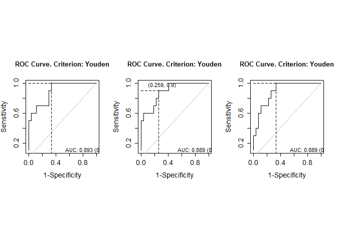

```r
par(mfrow=c(1,3))
plot(lm, which=1); plot(nn, which=1); plot(gbm1, which=1)
```